```python
%%html

Page Links — <a href="index.html" target="_self">Project Overview Page</a>
— <a href="page1.html" target="_self">Dataset Page</a>
— <a href="page2.html" target="_self">Data Imputation Page</a>
— <a href="page3.html" target="_self">Data Exploration Page</a>
— <a href="page4.html" target="_self">Data Modeling Page</a>
```

```python
# Toggle raw code on/off, from stackoverflow
from IPython.display import HTML

HTML('''<script>
code_show=true;
function code_toggle() {
 if (code_show){
 $('div.input').hide();
 } else {
 $('div.input').show();
 }
 code_show = !code_show
}
$( document ).ready(code_toggle);
</script>
<form action="javascript:code_toggle()"><input type="submit" value="Toggle raw code on/off"></form>''')
```

# Data Modeling

After our exploration of the data, we can now model store sales. We'll apply a variety of models to see what works best.

```python
# merge train and store
b = train.merge(store,how='left', left_on='Store', right_on='Store')

# drop irrelevant columns
j = b.drop(['Unnamed: 0', 'PromoInterval'], axis=1)

# fill any missing values
z = j.fillna(j.median(), inplace=True)

# get dummies for categorical variables
final = pd.get_dummies(z)

# create index for predictor and response variables
cols = [col for col in final.columns if col not in ['Date', 'Sales', 'LogSales']]
```

```python
x = final[cols].values
y = final['Sales'].values

# split the data
x_train, x_test, y_train, y_test = train_test_split(x, y, test_size = 0.3, random_state = 15)
```

```python
# linear regression
linear = Lin_Reg()
linear.fit(x_train,y_train)
lin_score_train = linear.score(x_train,y_train)
lin_score_test = linear.score(x_test,y_test)

# ridge regression
ridge = Ridge(alpha=3.0)
ridge.fit(x_train,y_train)
ridge_score_train = ridge.score(x_train,y_train)
ridge_score_test = ridge.score(x_test, y_test)

# decision tree
tree = DecisionTree()
tree.fit(x_train,y_train)
tree_score_train = tree.score(x_train,y_train)
tree_score_test = tree.score(x_test, y_test)
```

```python
score_df = pd.DataFrame({#'knn': knn_scores,
                         'linear train': lin_score_train,
                         'linear test': lin_score_test,
                         'ridge train': ridge_score_train,
                         'ridge test': ridge_score_test,
                         'tree train': tree_score_train,
                         'tree test': tree_score_test},
                          index=['R^2 value']
    )

score_df
```

|  | linear test | linear train | ridge test | ridge train | tree test | tree train |
| --- | --- | --- | --- | --- | --- | --- |
| R^2 value | 0.898793 | 0.899614 | 0.898793 | 0.899613 | 0.972464 | 0.999523 |

**Observations**:

- As we can see above, the decision tree seems to be doing the best job, as evidenced by very high values of the R_squared on the test set.That is most likely due to the binary nature of the variables given since the multiple linear regression assumes strict linearity between the response and each predictor. The results above along with the dataset nature indicate that the decision tree (or its sibling models) should perform the best. In order to find what models can we build off of this, we will do further visual analysis to notice any lags in the dataset.

# Further exploration

```python
print 'Median Sales value is ' + str(final['Sales'].median())
print 'Median Customers number is ' + str(final['Customers'].median())
```

```
Median Sales value is 5739.0
Median Customers number is 606.0
```

```python
# reassure values are properly imputed
final['Sales'].loc[(final['Sales'] == 0.0)] = 5764
final['Customers'].loc[(final['Customers'] == 0.0)] = 629
```

Let's plot a random store data to observe the trends.

```python
x_2 = final['Date'][final['Store']==2]
y_2 = final['Sales'][final['Store']==2]
```

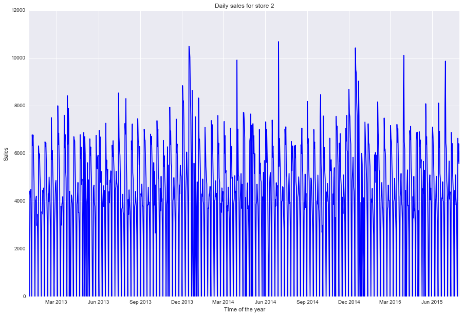

```python
fig, ax = plt.subplots(1, 1, figsize=(15, 10))

ax.plot(x_2, y_2, c='b', label='2013')
ax.set_xlabel('TIme of the year')
ax.set_ylabel('Sales')
ax.set_title('Daily sales for store 2')
```

With the imputed medians, the store sales clearly look like a time series. The seasonality might be present as well. Let's see what happens when we observe the autocorrelation among the data for year 2015.

```python
# found online
def plot_pacf(x, ax=None, lags=None, alpha=.05, method='ywm',
                use_vlines=True, **kwargs):

    fig, ax = plt.subplots(1, 1, figsize=(10, 5))

    if lags is None:
        lags = np.arange(len(x))
        nlags = len(lags) - 1
    else:
        nlags = lags
        lags = np.arange(lags + 1) # +1 for zero lag

    acf_x, confint = pacf(x, nlags=nlags, alpha=alpha, method=method)

    if use_vlines:
        ax.vlines(lags, [0], acf_x, **kwargs)
        ax.axhline(**kwargs)

    # center the confidence interval TODO: do in acf?
    confint = confint - confint.mean(1)[:,None]
    kwargs.setdefault('marker', 'o')
    kwargs.setdefault('markersize', 5)
    kwargs.setdefault('linestyle', 'None')
    ax.margins(.05)
    ax.plot(lags, acf_x, **kwargs)
    ax.fill_between(lags, confint[:,0], confint[:,1], alpha=.25)
    ax.set_title("Partial Autocorrelation")


    return fig
```

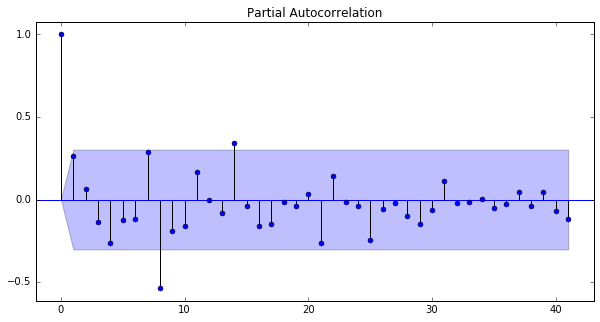

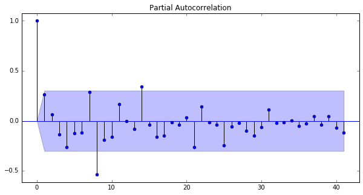

```python
plot_pacf(y[900:])
```

[figure not shown]

```python
fig, ax = plt.subplots(1, 1, figsize=(10, 5))
autocorrelation_plot(y[890:])
```

Looking at the graphs above, we can observe some spikes at 7, 14, and 21 days. We will use this information below in our VAR model.

# More suitable models

## VAR

```python
store_2 = final[final['Store']==2]
dates = final['Date'][final['Store']==2]
final_2 = store_2[['Sales', 'Customers', 'Open','Promo', 'SchoolHoliday']]
```

```python
train = final_2[:600]
test = final_2[600:]
```

```python
mdata = train
mdata.index = dates[:600]

model = VAR(mdata.values)

results = model.fit(maxlags=30, ic='aic')
results.summary()
```

```
  Summary of Regression Results
==================================
Model:                         VAR
Method:                        OLS
Date:           Thu, 15, Dec, 2016
Time:                     04:04:13
--------------------------------------------------------------------
No. of Equations:         5.00000    BIC:                    13.8826
Nobs:                     583.000    HQIC:                   11.9166
Log likelihood:          -6813.83    FPE:                    43115.8
AIC:                      10.6608    Det(Omega_mle):         21669.5
--------------------------------------------------------------------
Results for equation y1
=========================================================================
            coefficient       std. error           t-stat            prob
-------------------------------------------------------------------------
const       6170.164543      1000.959412            6.164           0.000
L1.y1         -0.001966         0.115467           -0.017           0.986
L1.y2         -1.110343         0.994069           -1.117           0.265
L1.y3       1155.644453       461.958347            2.502           0.013
L1.y4       1541.504374       312.274552            4.936           0.000
L1.y5      -1376.852144       253.896162           -5.423           0.000
L2.y1          0.053723         0.127903            0.420           0.675
L2.y2         -0.112116         1.148453           -0.098           0.922
L2.y3      -1098.295635       470.771784           -2.333           0.020
L2.y4       1147.085284       402.590229            2.849           0.005
L2.y5       1148.418576       339.422118            3.383           0.001
L3.y1         -0.177177         0.127556           -1.389           0.165
L3.y2          0.698986         1.148022            0.609           0.543
L3.y3        114.118311       478.209439            0.239           0.811
L3.y4       -386.810305       392.858207           -0.985           0.325
L3.y5         58.565927       340.013945            0.172           0.863
L4.y1         -0.027611         0.128811           -0.214           0.830
L4.y2          1.085448         1.150341            0.944           0.346
L4.y3      -1226.952869       478.298326           -2.565           0.011
L4.y4       1135.240650       399.397874            2.842           0.005
L4.y5        371.794213       338.152391            1.099           0.272
L5.y1          0.109702         0.128311            0.855           0.393
L5.y2          0.005159         1.148588            0.004           0.996
L5.y3       -907.850471       480.123767           -1.891           0.059
```

[output cut: 424 more lines]

```
L16.y5         0.100388         0.061005            1.646           0.100
L17.y1        -0.000038         0.000019           -1.975           0.049
L17.y2         0.000130         0.000172            0.758           0.449
L17.y3         0.181907         0.082692            2.200           0.028
L17.y4        -0.006761         0.066822           -0.101           0.919
L17.y5         0.010140         0.046584            0.218           0.828
=========================================================================

Correlation matrix of residuals
            y1        y2        y3        y4        y5
y1    1.000000  0.915051  0.766374  0.203119  0.025684
y2    0.915051  1.000000  0.780872  0.135622  0.010141
y3    0.766374  0.780872  1.000000  0.087712  0.006225
y4    0.203119  0.135622  0.087712  1.000000 -0.076187
y5    0.025684  0.010141  0.006225 -0.076187  1.000000
```

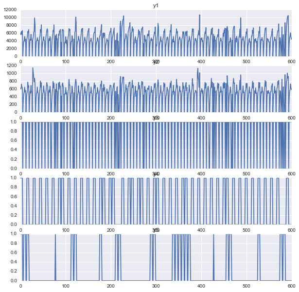

```python
results.plot()
```

The graph above shows the vector autoregression for each of the 5 variables (the function does it automatically). The first graph shows the regression for Sales and that is our object of interest. Given the complexity of the data, we decided to minimize the amount of predictor variables and our error below shows we did a good job. VAR managed to produce very decent results and outperform the decision tree. So far it is our best model.

```python
lag_order = results.k_ar
a = results.forecast(train.values[-lag_order:], 342)
sales_prediction = a[:,0]
sales_actual = test['Sales'].values
#sales_actual.shape
def rmse(predictions, targets):
    return np.sqrt(((predictions - targets) ** 2).mean())/10000

print 'The root mean square prediction error for VAR method is ' + str(rmse(sales_prediction, sales_actual))
```

```
The root mean square prediction error for VAR method is 0.160791973212
```

```python
sales_actual = final_2[600:]
sales_predicted =  sales_prediction
dates_2 = final['Date'][final['Store']==2][:342]
```

Let's plot the graph to visualize our VAR predictions.

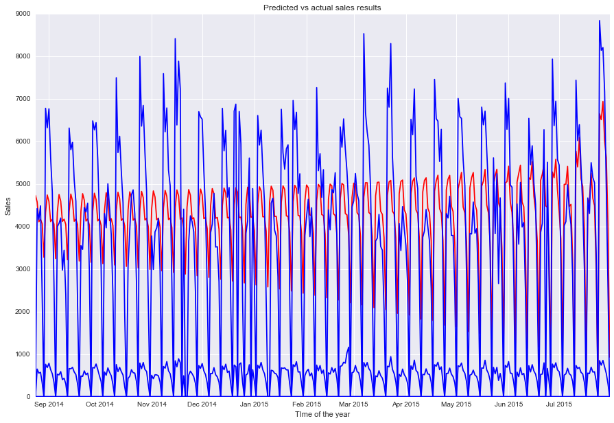

```python
fig, ax = plt.subplots(1, 1, figsize=(15, 10))

ax.plot(dates_2, sales_prediction, c='r', label='predicted sales')
ax.plot(dates_2, sales_actual, c='b', label='actual sales')
ax.set_xlabel('TIme of the year')
ax.set_ylabel('Sales')
ax.set_title('Predicted vs actual sales results')
```

## Tree revisited

While the tree had a good r-squared, let's see how it performs when it comes to RMSPE. Only then will we know how does it fare against vector autoregression.

```python
xtrain = train[['Customers', 'Open','Promo', 'SchoolHoliday']]
ytrain = train[['Sales']]

xtest = test[['Customers', 'Open','Promo', 'SchoolHoliday']]
ytest = test[['Sales']]

# new decision tree
tree = DecisionTree()
tree.fit(xtrain,ytrain)
tree_prediction = tree.predict(xtest)
original = ytest.values

rmse(original, tree_prediction)

print 'The root mean square prediction error for VAR method is ' + str(rmse(original, tree_prediction))
```

```
The root mean square prediction error for VAR method is 0.322624741027
```

As we can see, the tree performs approximately twice as bad as the VAR. It seems that the autoregression is better suited for the task given we are handling a time series data.